# Creating images with R

with a little bit of magick

Shu-Chi Lee

```css
h1,h2 {
    font-family: Georgia, serif;
}

body {
  font-family: "Gill Sans", sans-serif;
  background-image: url('https://i.pinimg.com/564x/66/0d/33/660d3326df8150a9fbee8e069af74128.jpg');
  background-repeat: repeat;
  color: #000000;
  background-size: 100%;
}

p {
    line-height: 1.8;
    margin-bottom: 15px;
    font-size: 15px;
}
div {
  background-color: rgba(255, 255, 255, 0.25)   /* 35% opaque white */;
  padding: 1em;
}
```

## Project requirements

Working on GitHub,I started by creating a repository called “stats220” and a README.md file. First of all,I created a header which using italics and unordered bullet points for describing some informations about me with emoji. Secondly,I made another header with same level as the first one but using ordered bullet points and links to other websites for putting the songs I have been listening recently. In the end,I put a different levels of header for leaving a short message “hopefully having fun in the class” and also put a gif.

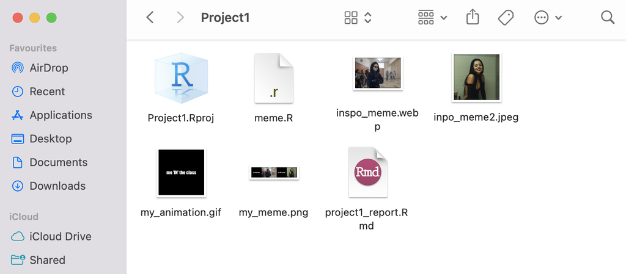

```r
screenshot <- image_read("screen_shot.png")
screenshot
```

## My meme

```r
# First meme
inpo1 <- image_read("https://media1.popsugar-assets.com/files/thumbor/-d4lbfPgifoamHBDu_ZV3h9A-AM=/fit-in/1584x1056/top/filters:format_auto():upscale()/2019/08/05/889/n/1922283/tmp_ygenWH_223803119ea27c8e_00496b651a0490188e454f739fd42ed58826b44d7e24b643f520148270385f76de4a51129224a79ce1e29a6ef887c2c2.jpg") %>%
  image_scale(750)

# Second meme
inpo2 <- image_read("https://i.pinimg.com/1200x/10/06/58/10065832a15fbe201a826503300772b2.jpg") %>%
  image_scale(500)

# First picture with text
text1 <- image_blank(width = 500,
                     height = 500,
                     color = "#000000") %>%
  image_annotate(text = "me 'IN' the class",
                 color = "#FFFFFF",
                 size = 50,
                 font = "Impact",
                 gravity = "center")

# Second picture with text
text2 <- image_blank(width = 500,
                     height = 500,
                     color = "#000000") %>%
  image_annotate(text = "me 'OFF' the class",
                 color = "#FFFFFF",
                 size = 50,
                 font = "Impact",
                 gravity = "center")

# Combine meme and picture with text
combine_meme <- c(text1,inpo1,text2,inpo2)

# Turning into png
png_meme <- image_append(combine_meme)
image_write(png_meme, "my_meme.png")
```

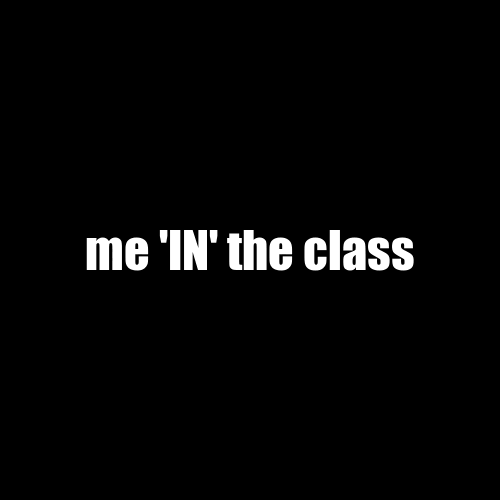

```r
# Turning into gif
gif_meme <- image_animate(combine_meme, fps = 1)

image_write(gif_meme, "my_animation.gif")
```

## Creativity

For creativity,I used more CSS than what was required to change the appearance of my HTML,such like change the body image and the fonts of both header and body. Also,I added a animated GIF in my GitHub repo.

## Learning reflection

One of the most important idea I learned from Moudle 1 is to actually create something as a result,since I used to only know how to caculate statistic stuff such like p-value or mean in RStudio,and I thought that is the only way I can use it,so it is really new and interesting for me to learn making our own meme or animated GIF and turn it into a html. Another idea which is important for me is that I realize that materials from class is not the only way I can learn. For example,I wanted to change more visual appearance of my html,so I searched many different ways and learned something more online.

The things related to data technologies that I am really curious about is what else we can bring about by using RStudio and coding.